## OSNOVE PROGRAMSKOG JEZIKA R

#### **Fakultet elektrotehnike i računarstva, Sveučilište u Zagrebu**

#### 9/2/2018

# **ZAVRŠNI ISPIT 2017/2018**

======================================================================================

#### JMBAG: 0036476746

#### Ime i prezime: Goran Brlas

#### e-mail: goran.brlas@fer.hr

#### IP adresa: 161.53.78.34

======================================================================================

#### OSNOVNE UPUTE

U nastavku slijedi niz zadataka za završni ispit. Rješenja zadatka mogu uključivati **upisivanje programskog koda** ili **čistog teksta** te **izvršavanje programskog koda**. Molimo da se pridržavate sljedećih naputaka:

- prije rješavanja stisnite gumb **Knit to HTML** kako bi provjerili ispravnost sučelja te dobili predložak ispita u preglednijem obliku u prozoru preglednika s desne strane
- ukoliko nije drugačije navedeno, prostor za rješavanje zadataka sami stvarate kombinacijom tipaka **CTRL+ALT+I** ili odabirom opcija **Insert -> R**
- pažljivo čitajte tekstove zadataka
- tekst zadatka može sadržavati i programski kod kojeg morate izmijeniti i nadopuniti te izvršiti već prema uputama danim u tekstu zadatka i / ili komentarima postojećeg programskog koda
- ukoliko je rješenje zadatka programski kod koji nešto ispisuje, budite sigurni da bilježnica uključuje i taj ispis
- programski kod slobodno komentirajte

Nakon ispunjavanja bilježnice odaberite opciju **Knit to HTML* i pohranite rezultat u HTML obliku u predviđeni repozitorij na *Moodle* stranicama predmeta.

Tijekom rješavanja bilježnice smijete se koristiti pomoćnim sredstvima kao što su podsjetnici, dokumentacija jezika R, bilježnice s predavanja, *Google* tražilica. **Ne smijete razmjenjivati informacije sa drugim polaznicima ispita bilo kojim vidom komunikacije, uključujući i elektroničku poštu, društvene mreže, chat programe ili korištenje zajedničkog dijeljenog repozitorija!**

Pohranom HTML bilježnice pod Vašim korisničkim imenom i lozinkom garantirate da tijekom ove provjere znanje niste od drugoga primili niti pružili pomoć te da se niste koristili nedopuštenim sredstvima. Ove su radnje povreda Kodeksa ponašanja te mogu uzrokovati trajno isključenje s Fakulteta.

Učitane podatke možete vidjeti u prozoru s gornje desne strane sučelja **RStudio**, tab *Environment**.

======================================================================================

## ZADACI

1. (2 boda) Uz pomoć jedne naredbe učinite sljedeće: odaberite 30 nasumičnih **cijelih** brojeva iz intervala [10, 20], oblikujte ih u matricu 5 x 6 (popunjavanje po retcima) te ispišite najveći element svakog stupca. Rješenje napišite ispod znaka `#`.

**RJEŠENJE:**

```r
set.seed(1234)
#

m <- matrix(ceiling(runif(30, 10, 20)), nrow = 5, ncol = 6, byrow = T)
m
print("=============================")
apply(m, 2, max)
```

```
##      [,1] [,2] [,3] [,4] [,5] [,6]
## [1,]   12   17   17   17   19   17
## [2,]   11   13   17   16   17   16
## [3,]   13   20   13   19   13   13
## [4,]   12   13   14   14   12   11
## [5,]   13   19   16   20   19   11
## [1] "============================="
## [1] 13 20 17 20 19 17
```

2. (4 boda) U datoteci `untidyIris.csv` nalazi se “neuredni” uzorak od 12 cvjetova iz podatkovnog okvira `iris` (dostupnog u R okruženju).
1. Učitajte podatke u podatkovni okvir `untidyIris` i objasnite zašto podatkovni okvir `untidyIris` predstavlja neuredne podatke.

```r
# prostor za programski kod
untidyIris <- read.csv("untidyIris.csv", header = T, stringsAsFactors = F)
head(untidyIris)
```

```
##   flowerId  FeatureName FeatureValue setosa versicolor virginica
## 1        1 Sepal.Length          5.1   TRUE      FALSE     FALSE
## 2        2 Sepal.Length          4.9   TRUE      FALSE     FALSE
## 3        3 Sepal.Length          4.7   TRUE      FALSE     FALSE
## 4        4 Sepal.Length          4.6   TRUE      FALSE     FALSE
## 5        5 Sepal.Length          7.0  FALSE       TRUE     FALSE
## 6        6 Sepal.Length          6.4  FALSE       TRUE     FALSE
```

ODGOVOR: Ovaj dataframe predstavlja neuredne podatke zato što se stupci FeatureName i FeatureValue ne odnose na istu stvar, odnosno za vrijednost od npr. 5.8 za neki zapis to može prestavljati “Sepal.Length”, dok za drugi zapis to može biti “Petal.Width”.

2. Napišite programski blok koji će urediti `untidyIris` (možete proučiti originalni podatkovni okvir `iris` za referencu). Ispišite konačni oblik okvira `untidyIris`.

**RJEŠENJE:**

```r
untidyIris2 <- spread(untidyIris, FeatureName, FeatureValue)
head(untidyIris2)
```

```
##   flowerId setosa versicolor virginica Petal.Length Petal.Width
## 1        1   TRUE      FALSE     FALSE          1.4         0.2
## 2        2   TRUE      FALSE     FALSE          1.4         0.2
## 3        3   TRUE      FALSE     FALSE          1.3         0.2
## 4        4   TRUE      FALSE     FALSE          1.5         0.2
## 5        5  FALSE       TRUE     FALSE          4.7         1.4
## 6        6  FALSE       TRUE     FALSE          4.5         1.5
##   Sepal.Length Sepal.Width
## 1          5.1         3.5
## 2          4.9         3.0
## 3          4.7         3.2
## 4          4.6         3.1
## 5          7.0         3.2
## 6          6.4         3.2
```

Zadaci 3. - 5. odnose se na podatkovni okvir `marioKart` iz paketa `openintro` koja sadržava cijene koje je postigla igra Mario Kart na aukcijskom portalu Ebay 2009. godine. Instalirajte navedeni paket i postavite podatkovni okvir u globalnu okolinu. proučite podatkovni okvir prije nastavljanja sa zadacima.

```r
# install.packages("openintro")   # ako je potrebno
#library(openintro)  # ako je potrebno
data(marioKart)

# head, glimpse, summary...
head(marioKart)
glimpse(marioKart)
```

```
##             ID duration nBids cond startPr shipPr totalPr     shipSp
## 1 150377422259        3    20  new    0.99   4.00   51.55   standard
## 2 260483376854        7    13 used    0.99   3.99   37.04 firstClass
## 3 320432342985        3    16  new    0.99   3.50   45.50 firstClass
## 4 280405224677        3    18  new    0.99   0.00   44.00   standard
## 5 170392227765        1    20  new    0.01   0.00   71.00      media
## 6 360195157625        3    19  new    0.99   4.00   45.00   standard
##   sellerRate stockPhoto wheels
## 1       1580        yes      1
## 2        365        yes      1
## 3        998         no      1
## 4          7        yes      1
## 5        820        yes      2
## 6     270144        yes      0
##                                                         title
```

[output cut: 20 more lines]

3. (6 bodova) Napišite naredbe koje će izvršiti sljedeće:
1. Za sve nove primjerke igre čiji opis sadrži riječi “brand new”, a koje je prodavao korisnik sa ratingom manjim od 1000 ispišite trajanje aukcije, broj ponuda, cijenu u dolarima i cijenu u kunama (ako prepostavimo da vrijedi $1 = 6 Kn).

**RJEŠENJE:**

```r
marioKart %>% filter(str_detect(tolower(marioKart$title), "brand new")) %>% filter(sellerRate < 1000) %>% select(duration, nBids, totalPr) -> tempdf
mutate(tempdf, totalPrKn = totalPr * 6)
```

```
##    duration nBids totalPr totalPrKn
## 1         3    18   44.00    264.00
## 2         1    20   71.00    426.00
## 3         1    15   56.01    336.06
## 4         1    16   56.00    336.00
## 5         3    23   46.00    276.00
## 6         1    19   55.00    330.00
## 7         7    15   47.00    282.00
## 8         1    20   56.00    336.00
## 9         1    22   63.50    381.00
## 10        1    13   45.00    270.00
## 11        1    19   61.00    366.00
## 12        1    14   62.89    377.34
```

2. Za sve kombinacije trajanja aukcije i stanja igre napišite prosječnu i maksimalnu postignutu cijenu. Pripazite da cijene budu zaokružene na dvije decimale. Ispis poredajte po trajanju aukcije uzlazno.

**RJEŠENJE:**

```r
marioKart %>% group_by(duration, cond) %>% summarise("meanPrice" = round(mean(totalPr, na.rm = T), 2), maxPrice = round(max(totalPr, na.rm = T), 2)) %>% arrange(duration)
```

```
## # A tibble: 9 x 4
## # Groups:   duration [5]
##   duration cond  meanPrice maxPrice
##      <int> <fct>     <dbl>    <dbl>
## 1        1 new        57.4     75.0
## 2        1 used       39.4     54.5
## 3        3 new        47.8     64.0
## 4        3 used       47.6    118
## 5        5 new        48.0     49.9
## 6        5 used       43.1     55.0
## 7        7 new        47.4     54.7
## 8        7 used       52.0    327
## 9       10 used       37.2     43.4
```

4. (6 bodova) Napišite naredbe koje će izvesti sljedeće:
1. Nacrtati točkasti graf odnosa rating-a prodavatelja sa postignutom cijenom. Točke na grafu se moraju razlikovati ovisno o stanju igre. Graf mora imati i naznačen linearni trend (zajednički za oba stanja igre). Graf ne smije uključivati obzervacije kod kojih je rating prodavatelja iznad 1000 a cijena iznad 100 dolara.

**RJEŠENJE:**

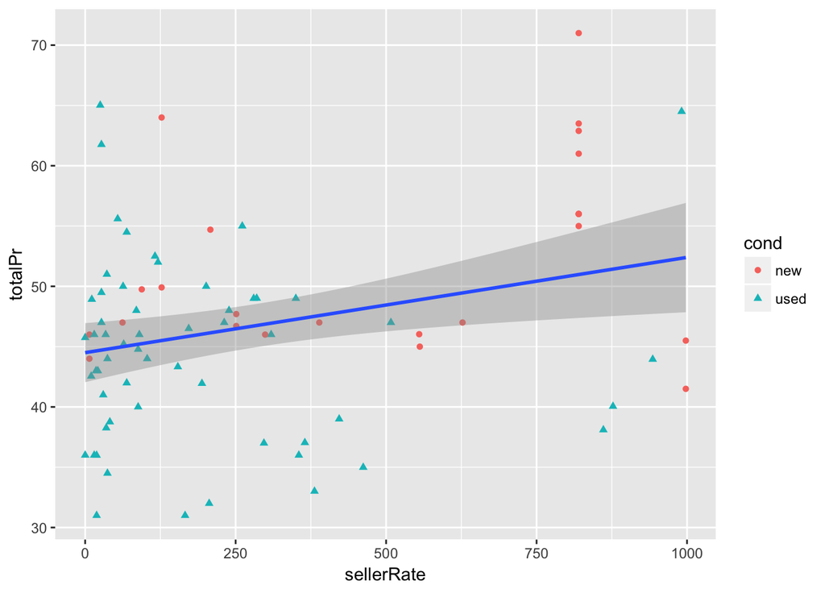

```r
ggplot(filter(marioKart, sellerRate <= 1000 & totalPr <= 100), aes(x = sellerRate, y = totalPr)) + geom_point(aes(color = cond, shape = cond)) + stat_smooth(method=lm)
```

2. Nacrtati histograme ukupno postignute cijene igre u ovisnosti o stanju igre (dva histograma, jedan iznad drugog). Cijena mora biti podijeljena u pet ladica. Stupići histograma moraju svojom bojom naznačavati informaciju o načinu slanja pošiljke a stupići različitih boja moraju biti posloženi jedan pokraj drugog.

**RJEŠENJE:**

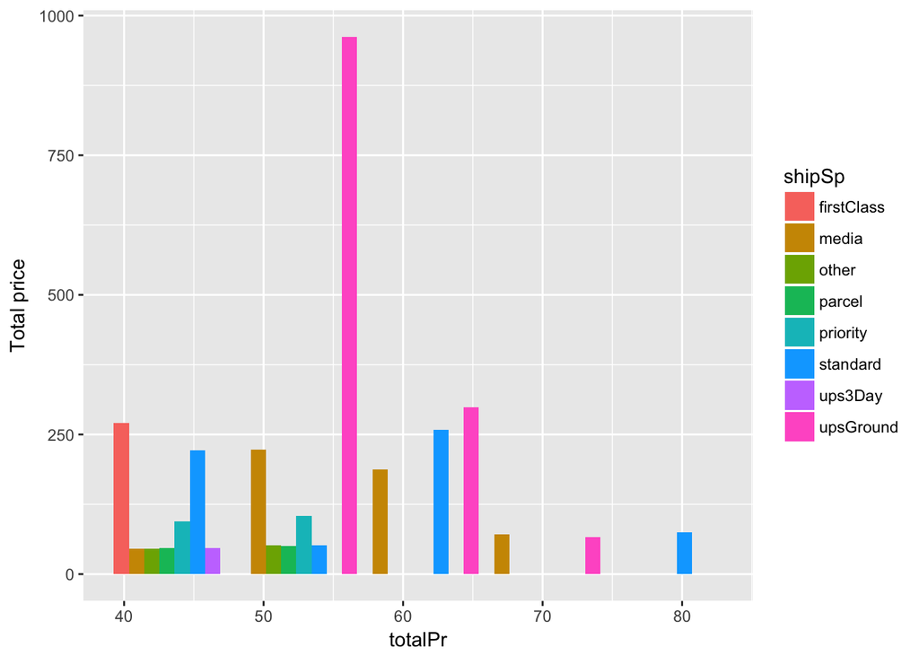

```r
ggplot(filter(marioKart, cond == "new"), aes(fill = shipSp)) +
  geom_histogram(aes(x=totalPr, weights=totalPr), bins = 5, position="dodge") +
  ylab("Total price")
```

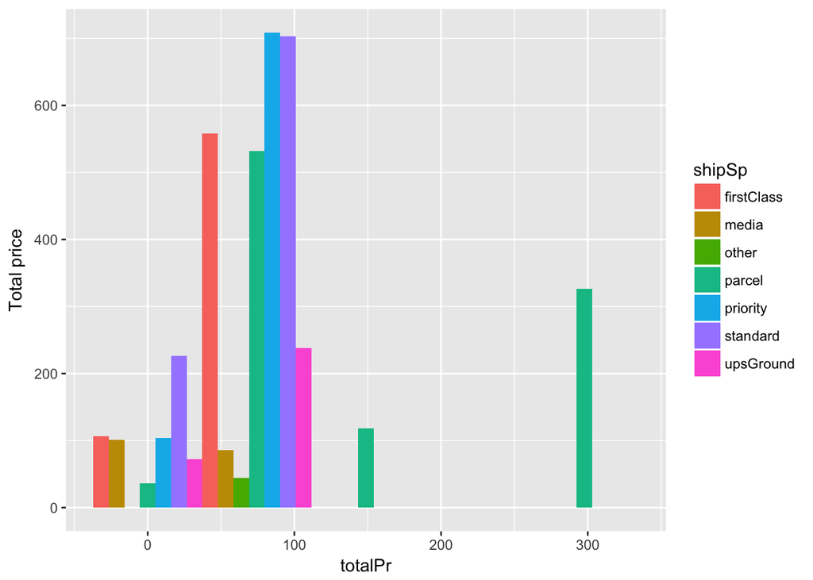

```r
ggplot(filter(marioKart, cond == "used"), aes(fill = shipSp)) +
  geom_histogram(aes(x=totalPr, weights=totalPr), bins = 5, position="dodge") +
  ylab("Total price")
```

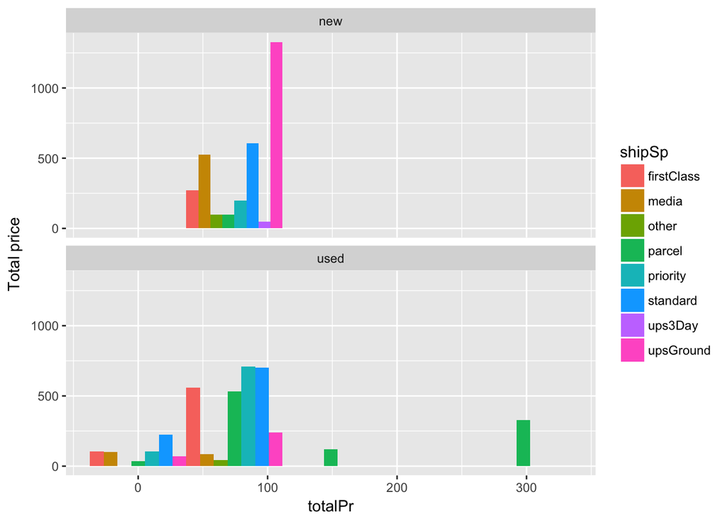

```r
ggplot(marioKart, aes(fill = shipSp)) +
  geom_histogram(aes(x=totalPr, weights=totalPr), bins = 5, position="dodge") +
  ylab("Total price") + facet_wrap(facets = ~ cond, nrow = 2)
```

5. (4 boda) Istrenirajte model linearne regresije ovisnosti ukupne cijene o stanju igre. Proučite dobiveni linearni model i odgovorite na pitanja:
1. kako se mijenja cijena s obzirom na različito stanje igre?
2. smatrate li da je stanje igre bitan čimbenik u konačnoj cijeni? Obrazložite.

**RJEŠENJE:**

```r
linMod <- lm(totalPr ~ cond, marioKart)
linMod

summary(linMod)
```

```
##
## Call:
## lm(formula = totalPr ~ cond, data = marioKart)
##
## Coefficients:
## (Intercept)     condused
##      53.771       -6.623
##
##
## Call:
## lm(formula = totalPr ~ cond, data = marioKart)
##
## Residuals:
##     Min      1Q  Median      3Q     Max
## -18.168  -7.771  -3.148   1.857 279.362
##
## Coefficients:
##             Estimate Std. Error t value Pr(>|t|)
## (Intercept)   53.771      3.329  16.153   <2e-16 ***
## condused      -6.623      4.343  -1.525     0.13
## ---
## Signif. codes:  0 '***' 0.001 '**' 0.01 '*' 0.05 '.' 0.1 ' ' 1
##
## Residual standard error: 25.57 on 141 degrees of freedom
## Multiple R-squared:  0.01622,    Adjusted R-squared:  0.009244
## F-statistic: 2.325 on 1 and 141 DF,  p-value: 0.1296
```

ODGOVOR:

1. S promjenom stanja igre cijena pada za cca 6.6 dolara.
2. Smatram da stanje igre nije toliko bitan čimbenik zato što promjena stanja utječe na promjenu igre samo cca 12%, što nije statistički toliko značajno budući da imamo samo 2 moguća stanja. Također, ovu tvrdnju potvrđuje sljedeći zadatak u kojem postepeno gradimo modele i gdje u konačnici možemo vidjeti da stanje igre nije jedna od varijabli koje se koriste za predikciju.
6. (3 boda) Postupno izgradite model linearne regresije za određivanje konačne cijene igre metodom “unatrag od punog modela” i “unaprijed od praznog modela”. Iz podatkovnog okvira prethodno izbacite stupce `"ID"` i `"title"`. Ispišite sažetak dobivenih modela. Proučite modele i odgovorite: koja dva atributa smatrate ključnima u formiranju konačne cijene?

**RJEŠENJE:**

```r
lm_sve <- lm(totalPr ~ ., data = select(marioKart, -ID, -title))
lm_prazan <- lm(totalPr ~ 1, data = select(marioKart, -ID, -title))

lm1 <- stepAIC(lm_sve, direction = "backward")
summary(lm1)
print("====================================")
print("====================================")
print("====================================")
lm2 <- stepAIC(lm_prazan, direction = "forward", scope = list(upper = lm_sve, lower = lm_prazan))
summary(lm2)
```

```
## Start:  AIC=866.14
## totalPr ~ duration + nBids + cond + startPr + shipPr + shipSp +
##     sellerRate + stockPhoto + wheels
##
##              Df Sum of Sq   RSS    AIC
## - shipSp      7    3958.1 52782 863.28
## - sellerRate  1       0.5 48824 864.14
## - cond        1      63.7 48887 864.32
## <none>                    48824 866.14
## - startPr     1     807.2 49631 866.48
## - stockPhoto  1     818.9 49643 866.52
## - duration    1    1224.7 50048 867.68
## - nBids       1    1968.3 50792 869.79
## - wheels      1    3210.1 52034 873.24
## - shipPr      1   23135.3 71959 919.60
##
## Step:  AIC=863.28
## totalPr ~ duration + nBids + cond + startPr + shipPr + sellerRate +
##     stockPhoto + wheels
##
##              Df Sum of Sq   RSS    AIC
## - cond        1      13.1 52795 861.32
## - sellerRate  1      71.1 52853 861.48
## - stockPhoto  1     710.5 53492 863.20
## <none>                    52782 863.28
## - duration    1     889.9 53672 863.67
## - startPr     1    1332.8 54115 864.85
## - nBids       1    3042.1 55824 869.30
## - wheels      1    4273.3 57055 872.42
## - shipPr      1   24334.0 77116 915.50
##
## Step:  AIC=861.32
## totalPr ~ duration + nBids + startPr + shipPr + sellerRate +
##     stockPhoto + wheels
##
##              Df Sum of Sq   RSS    AIC
## - sellerRate  1      80.5 52875 859.54
## - stockPhoto  1     708.7 53504 861.23
## <none>                    52795 861.32
## - duration    1    1026.8 53822 862.07
```

[output cut: 137 more lines]

```
##
## Coefficients:
##             Estimate Std. Error t value Pr(>|t|)
## (Intercept)  14.6283     7.1980   2.032 0.044060 *
## shipPr        4.3593     0.5431   8.026 4.05e-13 ***
## wheels        7.8838     2.1257   3.709 0.000302 ***
## nBids         1.0175     0.3660   2.780 0.006197 **
## startPr       0.3000     0.1450   2.068 0.040489 *
## duration     -1.0353     0.7195  -1.439 0.152419
## ---
## Signif. codes:  0 '***' 0.001 '**' 0.01 '*' 0.05 '.' 0.1 ' ' 1
##
## Residual standard error: 19.77 on 137 degrees of freedom
## Multiple R-squared:  0.4286, Adjusted R-squared:  0.4077
## F-statistic: 20.55 on 5 and 137 DF,  p-value: 2.846e-15
```

Odgovor: Ključni atributi za formiranje cijene su cijena shippinga te broj Wii volana.